# Part I - (GoBike System Data Exploration)

## by (Amjad Almutairi)

## Introduction

> This data set includes information about a bike-sharing system, Ford GoBike system, in California's San Francisco Bay Area.

## Investigation Overview

> In this investigation, I wanted to look at the characteristics of Users that could be used to predict the Trip duration. The main focus was on the User Type, Age, and Gender.and duration

## Dataset Overview

> The dataset consisted of Trip Duration and attributes of approximately 18,3500 Ford GoBike Users. The attributes included the User Type, Gender, User Birth Date, as well as additional measurements such as Station location,Trip Start Time - End Time. Some Columns were removed from the analysis due to no need for them, age of User is added, and Trip Duration converted from seconds to Minutesfor more readability

## Univariate Exploration

# What is the most type of the users ?

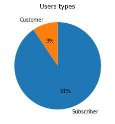

As shown in the pie char subscriber users are higher than customers in using the bikes.

# what the Most stations the start is same to end station?

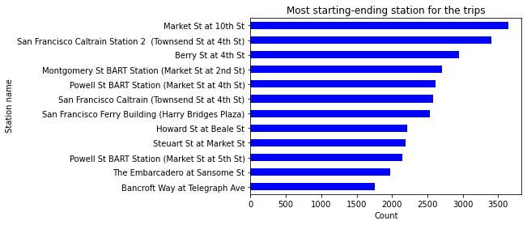

## What is the most day of the week trips?

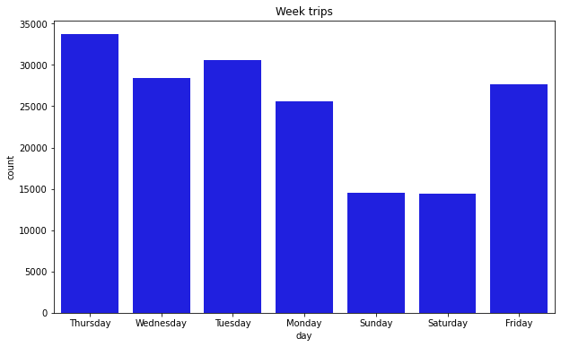

### when looking at the figure isThursday has the most rides almost 35000

## Bivariate Exploration

> In this section, investigate relationships between pairs of variables in your data. Make sure the variables that you cover here have been introduced in some fashion in the previous section (univariate exploration).

## Effect of Age on the Trip Duration?

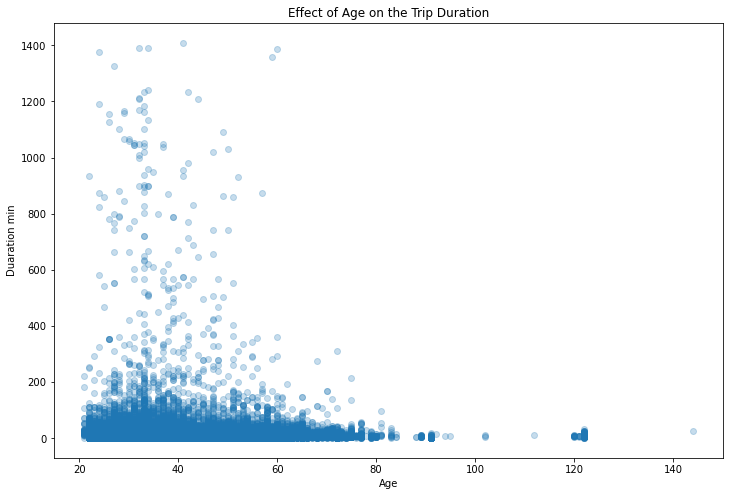

## Multivariate Exploration

> Create plots of three or more variables to investigate your data even further. Make sure that your investigations are justified, and follow from your work in the previous sections.

## clustered bar chart views the higher Trip Duration between males and females the Male Subscribers show the lowest Trip duration compared with female and other Subscriber

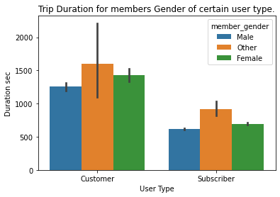

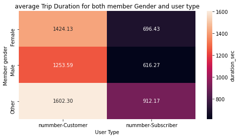

## Conclusions

> finally The data consisted of Trip Duration and attributes of approximately 183500 Ford GoBike Users. The attributes included the User Type, Gender, User Birth Date, as well as additional measurements such as Station location,Trip Start Time - End Time. Some Columns were removed from the analysis due to no need for them, age of User is added, and Trip Duration converted from seconds to Minutesfor more readability.